# Practical Machine Learning Course Project

Tanmoy Rath

16 January 2019

## Dataset Background

The weight-lifting dataset used in this analysis was provided by [Groupware@LES](http://groupware.les.inf.puc-rio.br/). You can find more information about it on:

- http://groupware.les.inf.puc-rio.br/har (see the section on the Weight Lifting Exercise Dataset)
- http://groupware.les.inf.puc-rio.br/work.jsf?p1=11201 (their research paper using the dataset)

6 young health participants were asked to perform one set of 10 repetitions of the Unilateral Dumbbell Biceps Curl in five different fashions:

- **Class A**, exactly according to the specification,
- **Class B**, throwing the elbows to the front,
- **Class C**, lifting the dumbbell only halfway,
- **Class D**, lowering the dumbbell only halfway &
- **Class E**, throwing the hips to the front.

Class A corresponds to the specified execution of the exercise, while the other 4 classes correspond to common mistakes.

**The goal of my project is to predict the manner in which they did the exercise** or in other words, to determine the class. This is to be determined by analyzing the data from various accelerometers on the belt, forearm, arm, and dumbell of the 6 participants.

## Data Cleaning

```r
training <- read.csv(file = "pml-training.csv", na.strings = c("","NA"))
```

On looking at the dataset, I found that a **lot of columns containd NA values**, before doing any imputation, I calculated the % of NA per column. I stored the result in NA_Colmns variable.

```r
NA_Colmns <- 100 * colSums(is.na(training)) / (dim(training)[1])
```

**Those columns that have more than 80% values as NA, were removed them from the dataset**.

```r
NA_Colmns <- NA_Colmns > 80
training <- training[, ! NA_Colmns]
```

**Next, I removed the columns that measured time (timestamps & window), sequences(X) and User Names, because such data would confound the prediction which was to be done solely on data from accelerometers.**

```r
drops <- c("X", "user_name", "raw_timestamp_part_1", "raw_timestamp_part_2",
           "cvtd_timestamp", "new_window", "num_window")

remv_colms <- colnames(training) %in% drops
training <- training[, !remv_colms]
```

I also checked for any **near zero variance predictors** and found none.

```r
suppressMessages(library(caret))
nearZeroVar(training,saveMetrics=FALSE)
```

```
## integer(0)
```

## Data Exploration

**Density plots of columns**  
Some of the columns of training data are highly skewed, indicating presence of outliers. They are (with outlier values):

- gyros_dumbbell_x (-204), gyros_dumbbell_y (52), gyros_dumbbell_z (317)
- gyros_forearm_x (-22), gyros_forearm_y (311), gyros_forearm_z (231)
- magnet_dumbbell_y (-3600)

2 of the density plots are shown below (with outlier values).

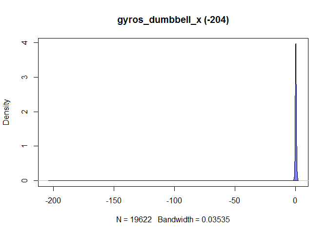

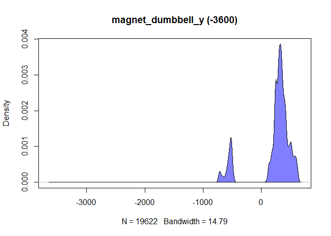

#### Outliers Treatment

Only 2 rows were found containing these outliers. Therefore, those rows containg these outliers were removed. The loss in data is negligible considering there are 19620 remaining observations.

```r
training <- training[training$gyros_dumbbell_x != -204,]
training <- training[training$gyros_dumbbell_y != 52,]
training <- training[training$gyros_dumbbell_z != 317,]

training <- training[training$gyros_forearm_x != -22,]
training <- training[training$gyros_forearm_y != 311,]
training <- training[training$gyros_forearm_z != 231,]

training <- training[training$magnet_dumbbell_y != -3600,]
```

**After cleaning, the new training dataset contained only 53 columns out of 19620 observations.**

```r
str(training)
```

```
## 'data.frame':    19620 obs. of  53 variables:
##  $ roll_belt           : num  1.41 1.41 1.42 1.48 1.48 1.45 1.42 1.42 1.43 1.45 ...
##  $ pitch_belt          : num  8.07 8.07 8.07 8.05 8.07 8.06 8.09 8.13 8.16 8.17 ...
##  $ yaw_belt            : num  -94.4 -94.4 -94.4 -94.4 -94.4 -94.4 -94.4 -94.4 -94.4 -94.4 ...
##  $ total_accel_belt    : int  3 3 3 3 3 3 3 3 3 3 ...
##  $ gyros_belt_x        : num  0 0.02 0 0.02 0.02 0.02 0.02 0.02 0.02 0.03 ...
##  $ gyros_belt_y        : num  0 0 0 0 0.02 0 0 0 0 0 ...
##  $ gyros_belt_z        : num  -0.02 -0.02 -0.02 -0.03 -0.02 -0.02 -0.02 -0.02 -0.02 0 ...
##  $ accel_belt_x        : int  -21 -22 -20 -22 -21 -21 -22 -22 -20 -21 ...
##  $ accel_belt_y        : int  4 4 5 3 2 4 3 4 2 4 ...
##  $ accel_belt_z        : int  22 22 23 21 24 21 21 21 24 22 ...
##  $ magnet_belt_x       : int  -3 -7 -2 -6 -6 0 -4 -2 1 -3 ...
##  $ magnet_belt_y       : int  599 608 600 604 600 603 599 603 602 609 ...
##  $ magnet_belt_z       : int  -313 -311 -305 -310 -302 -312 -311 -313 -312 -308 ...
##  $ roll_arm            : num  -128 -128 -128 -128 -128 -128 -128 -128 -128 -128 ...
```

[output cut: 39 more lines]

## Data Splitting

Since the **pml-testing.csv** file doesnot contain any classe column, it could not be used for testing purposes. Hence the training data was split into **myTrain** and **myTest** of 0.75 and 0.25 parts respectively.

- **training** = **75%**(=myTrain) + **25%**(=myTest)

```r
set.seed(33492)
library(caret)
inTrain <- createDataPartition( y=training$classe, p=0.75, list = FALSE )
myTrain <- training[inTrain,]
myTest <- training[-inTrain,]
```

## Model : Random Forest

- The myTrain data was cross-validated 7 times on the optimal random forest, and from that, the out of sample error was calculated. I used cross-validation of K = 7 so that it isnt very high to introduce more variance, neither too low to introduce any bias.
- ntree = 400 was used because it had lesser prediction error on myTest, than default ntree=500.
- Setting importance to TRUE allowed the model to build efficient tress based on variable importance which reduces error.
- I also used parallel processing to reduce the time needed to build the model.

#### Parallel Processing

Using the parallel and doParallel packages, it is possible to build trees in parallel.

```r
set.seed(33492)
suppressMessages(library(parallel))
suppressMessages(library(doParallel))
cluster <- makeCluster(detectCores() - 1)
registerDoParallel(cluster)

fitControl <- trainControl(method = "cv", number = 7, returnData = FALSE, allowParallel = TRUE)

modelFit <- train(classe ~.,
                  data = myTrain,
                  method = "rf",
                  ntree = 400,
                  importance = TRUE,
                  trControl = fitControl)

stopCluster(cluster)
registerDoSEQ()
```

## Model’s Accuracy

The accuracy of the model has been measured in various ways.

#### 1. Optimal “mtry” accuracy = 99.30695%

```r
modelFit
```

```
## Random Forest
##
## No pre-processing
## Resampling: Cross-Validated (7 fold)
## Summary of sample sizes: 12616, 12616, 12613, 12614, 12614, 12614, ...
## Resampling results across tuning parameters:
##
##   mtry  Accuracy   Kappa
##    2    0.9919825  0.9898575
##   27    0.9930695  0.9912326
##   52    0.9866825  0.9831526
##
## Accuracy was used to select the optimal model using the largest value.
## The final value used for the model was mtry = 27.
```

#### 2. Average cross-validation accuracy = 99.30695%

The accuracy obtained by averaging the accuracy of each cross-validation fold, which is same as Optimal “mtry” Accuracy.

```r
cv_folds <- modelFit$resample
cv_folds
```

```
##    Accuracy     Kappa Resample
## 1 0.9923846 0.9903658    Fold1
## 2 0.9914449 0.9891768    Fold3
## 3 0.9961923 0.9951828    Fold2
## 4 0.9933428 0.9915785    Fold5
## 5 0.9961959 0.9951879    Fold4
## 6 0.9909610 0.9885659    Fold7
## 7 0.9909653 0.9885710    Fold6
```

```r
acc <- mean(  cv_folds$Accuracy  )*100
acc
```

```
## [1] 99.30695
```

#### 3. Out of sample error = 0.6930462%

This can be calculated as 100 - average cross validation accuracy i.e. **100 - acc**.

```r
100 - acc
```

```
## [1] 0.6930462
```

#### 4. Final Model OOB error rate = 0.58%

This is very very close to the out of sample error.

```r
modelFit$finalModel
```

```
##
## Call:
##  randomForest(x = x, y = y, ntree = 400, mtry = param$mtry, importance = TRUE)
##                Type of random forest: classification
##                      Number of trees: 400
## No. of variables tried at each split: 27
##
##         OOB estimate of  error rate: 0.58%
## Confusion matrix:
##      A    B    C    D    E  class.error
## A 4181    2    2    0    0 0.0009557945
## B   15 2826    5    1    0 0.0073761855
## C    0   10 2548    9    0 0.0074016362
## D    0    1   26 2383    2 0.0120232172
## E    0    2    4    7 2693 0.0048041390
```

#### 5. Accuracy on the whole training set = 99.89%

```r
confusionMatrix(   training$classe,   predict( modelFit$finalModel, newdata = training )   )
```

```
## Confusion Matrix and Statistics
##
##           Reference
## Prediction    A    B    C    D    E
##          A 5575    3    1    0    0
##          B    4 3791    1    0    0
##          C    0    1 3419    2    0
##          D    0    0    9 3207    0
##          E    0    0    0    1 3606
##
## Overall Statistics
##
##                Accuracy : 0.9989
##                  95% CI : (0.9983, 0.9993)
##     No Information Rate : 0.2844
##     P-Value [Acc > NIR] : < 2.2e-16
##
##                   Kappa : 0.9986
##  Mcnemar's Test P-Value : NA
##
## Statistics by Class:
##
##                      Class: A Class: B Class: C Class: D Class: E
## Sensitivity            0.9993   0.9989   0.9968   0.9991   1.0000
## Specificity            0.9997   0.9997   0.9998   0.9995   0.9999
## Pos Pred Value         0.9993   0.9987   0.9991   0.9972   0.9997
## Neg Pred Value         0.9997   0.9997   0.9993   0.9998   1.0000
## Prevalence             0.2844   0.1934   0.1748   0.1636   0.1838
## Detection Rate         0.2841   0.1932   0.1743   0.1635   0.1838
## Detection Prevalence   0.2844   0.1935   0.1744   0.1639   0.1838
## Balanced Accuracy      0.9995   0.9993   0.9983   0.9993   1.0000
```

#### Accuracy Summary

- **Optimal “mtry” accuracy = 99.30695%**
- **Average cross-validation accuracy = 99.30695%**
- **Out of sample error = 0.6930462%** (100 - average cross validation accuracy)
- **Final Model OOB error rate = 0.58%**
- **Accuracy on the whole training set = 99.89%**

## Model Plots

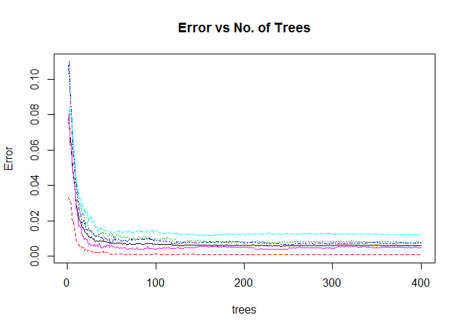

```r
plot( modelFit$finalModel, main="Error vs No. of Trees" )
```

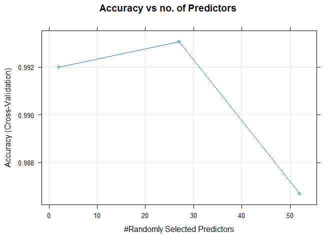

```r
plot(modelFit, main="Accuracy vs no. of Predictors")
```

## Prediction

#### 1. Prediction accuracy on myTest

Prediction accuracy on myTest was found to be **99.55%**.

```r
confusionMatrix(   myTest$classe,   predict( modelFit$finalModel, newdata = myTest )   )
```

```
## Confusion Matrix and Statistics
##
##           Reference
## Prediction    A    B    C    D    E
##          A 1390    3    1    0    0
##          B    4  944    1    0    0
##          C    0    1  852    2    0
##          D    0    0    9  795    0
##          E    0    0    0    1  900
##
## Overall Statistics
##
##                Accuracy : 0.9955
##                  95% CI : (0.9932, 0.9972)
##     No Information Rate : 0.2843
##     P-Value [Acc > NIR] : < 2.2e-16
##
##                   Kappa : 0.9943
##  Mcnemar's Test P-Value : NA
##
## Statistics by Class:
##
##                      Class: A Class: B Class: C Class: D Class: E
## Sensitivity            0.9971   0.9958   0.9873   0.9962   1.0000
## Specificity            0.9989   0.9987   0.9993   0.9978   0.9998
## Pos Pred Value         0.9971   0.9947   0.9965   0.9888   0.9989
## Neg Pred Value         0.9989   0.9990   0.9973   0.9993   1.0000
## Prevalence             0.2843   0.1934   0.1760   0.1628   0.1836
## Detection Rate         0.2835   0.1925   0.1738   0.1621   0.1836
## Detection Prevalence   0.2843   0.1936   0.1744   0.1640   0.1838
## Balanced Accuracy      0.9980   0.9973   0.9933   0.9970   0.9999
```

#### 2. Prediction on pml-testing.csv

The pml data was first cleaned. After that the final model was applied for prediction.

```r
testing <- read.csv(file = "pml-testing.csv", na.strings = c("","NA"))

NA_Colmns <- (     colSums(is.na(testing)) / (dim(testing)[1])     ) > 0.8
testing <- testing[, !NA_Colmns]

drops <- c("X", "user_name", "raw_timestamp_part_1", "raw_timestamp_part_2",
           "cvtd_timestamp", "new_window", "num_window", "problem_id")
remv_colms <- colnames(testing) %in% drops
testing <- testing[, !remv_colms]



predict( modelFit$finalModel ,newdata = testing )
```

```
##  1  2  3  4  5  6  7  8  9 10 11 12 13 14 15 16 17 18 19 20
##  B  A  B  A  A  E  D  B  A  A  B  C  B  A  E  E  A  B  B  B
## Levels: A B C D E
```

## Conclusion

The random forest is a very powerful machine learning algorithm. If time permits, with properly tuned parameters, the model’s accuracy can be greately amplified. On the training set (pml-training.csv), my model’s accuracy was found to be **99.89%**, while the cross-validated(k=7) out of sample error was found to be **0.6930462%**.